# In-Class Activity: Inference in Simple Linear Regression

# Learning goals

By the end of this activity, you should be able to:

- explain why regression estimates vary across samples;
- interpret a regression with a binary explanatory variable;
- conduct hypothesis tests about zero and nonzero coefficient values;
- construct and interpret confidence intervals;
- connect a binary-regressor model to a difference in group means; and
- compare conventional and unequal-variance standard errors.

# 1. Set up and inspect the data

We will use `wage2` from the `wooldridge` package. Each observation represents one worker. Our main variables of interest are:

- `wage`: monthly earnings in dollars;
- `lwage`: the natural log of monthly earnings;
- `educ`: years of education; and
- `urban`: an indicator equal to 1 if the worker lives in an urban area and 0 otherwise.

```r
library(wooldridge)
library(tidyverse)
library(knitr)
library(kableExtra)
```

```r
data("wage2")

# Open the documentation and inspect the variables
?wage2

# Check the sample size and missing values
wage2 |>
  select(wage, lwage, educ, urban) |>
  glimpse()
```

```
## Rows: 935
## Columns: 4
## $ wage  <int> 769, 808, 825, 650, 562, 1400, 600, 1081, 1154, 1000, 930, 921, …
## $ lwage <dbl> 6.645091, 6.694562, 6.715384, 6.476973, 6.331502, 7.244227, 6.39…
## $ educ  <int> 12, 18, 14, 12, 11, 16, 10, 18, 15, 12, 18, 14, 15, 16, 16, 10, …
## $ urban <int> 1, 1, 1, 1, 1, 1, 1, 1, 0, 1, 0, 0, 0, 1, 1, 1, 1, 1, 1, 1, 1, 1…
```

```r
wage2 |>
  summarise(
    `Sample size` = n(),
    across(c(wage, lwage, educ, urban), ~ sum(is.na(.x)), .names = "missing_{.col}")
  ) |>
  rename(
    `Missing wage values` = missing_wage,
    `Missing log wage values` = missing_lwage,
    `Missing education values` = missing_educ,
    `Missing urban-status values` = missing_urban
  ) |>
  knitr::kable(
    caption = "Sample size and missing values for variables used in the activity",
    align = c("r", "r", "r", "r", "r")
  ) |>
  kableExtra::kable_styling(full_width = FALSE, position = "left") |>
  kableExtra::row_spec(0, bold = TRUE)
```

Sample size and missing values for variables used in the activity

| Sample size | Missing wage values | Missing log wage values | Missing education values | Missing urban-status values |
| --- | --- | --- | --- | --- |
| 935 | 0 | 0 | 0 | 0 |

1. What is the unit of observation? What are the units of `wage`, `lwage`, and `educ`?

Each observation is one worker. wage is monthly earnings in dollars, lwage is its natural log, and educ is years of education.

2. Use a frequency table to verify how `urban` is coded. Which category is the reference group when `urban = 0`?

```r
# Create an accessible frequency table for urban
wage2 |>
  mutate(
    `Urban status` = case_when(
      urban == 0 ~ "Non-urban",
      urban == 1 ~ "Urban",
      TRUE ~ "Missing"
    )
  ) |>
  count(`Urban status`, name = "Number of workers") |>
  mutate(
    Percent = round(100 * `Number of workers` / sum(`Number of workers`), 1)
  ) |>
  knitr::kable(
    caption = "Frequency distribution of workers by urban status",
    col.names = c("Urban status", "Number of workers", "Percent of sample"),
    align = c("l", "r", "r")
  ) |>
  kableExtra::kable_styling(full_width = FALSE, position = "left") |>
  kableExtra::row_spec(0, bold = TRUE)
```

Frequency distribution of workers by urban status

| Urban status | Number of workers | Percent of sample |
| --- | --- | --- |
| Non-urban | 264 | 28.2 |
| Urban | 671 | 71.8 |

urban = 1 indicates an urban resident; urban = 0 indicates a non-urban resident and is the regression reference group.

# 2. Compare the two groups

Create a labeled factor called `urban_status`, then calculate the sample size, mean log earnings, standard deviation, and variance for each group.

Note: these grouped statistics are much easier to do using `dplyr` (a package inside `tidyverse`)! this is much easier to do using dplyr!

[Click this link to check out some examples.](https://tavareshugo.github.io/r-intro-tidyverse-gapminder/06-grouped_operations_dplyr/index.html)

```r
wage2 <- wage2 |>
  mutate(
    urban_status = factor(
      urban,
      levels = c(0, 1),
      labels = c("Non-urban", "Urban")
    )
  )

# Create the group summary
group_summary <- wage2 |>
  group_by(urban_status) |>
  summarise(
    n = n(),
    mean_lwage = mean(lwage),
    sd_lwage = sd(lwage),
    variance_lwage = var(lwage),
    .groups = "drop"
  )

group_summary |>
  rename(
    `Urban status` = urban_status,
    `Number of workers` = n,
    `Mean log monthly earnings` = mean_lwage,
    `Standard deviation of log monthly earnings` = sd_lwage,
    `Variance of log monthly earnings` = variance_lwage
  ) |>
  mutate(
    across(
      c(
        `Mean log monthly earnings`,
        `Standard deviation of log monthly earnings`,
        `Variance of log monthly earnings`
      ),
      ~ round(.x, 3)
    )
  ) |>
  knitr::kable(
    caption = "Summary statistics for log monthly earnings by urban status",
    align = c("l", "r", "r", "r", "r")
  ) |>
  kableExtra::kable_styling(full_width = FALSE, position = "left") |>
  kableExtra::row_spec(0, bold = TRUE)
```

Summary statistics for log monthly earnings by urban status

| Urban status | Number of workers | Mean log monthly earnings | Standard deviation of log monthly earnings | Variance of log monthly earnings |
| --- | --- | --- | --- | --- |
| Non-urban | 264 | 6.642 | 0.396 | 0.157 |
| Urban | 671 | 6.833 | 0.419 | 0.176 |

3. Which group has the larger mean log earnings? Calculate the raw difference as urban mean minus non-urban mean.

The urban group has the larger mean log earnings. The raw difference is 0.191 log points.

Create a boxplot comparing log earnings across the groups. Use informative labels, accessible colors, and alt text.

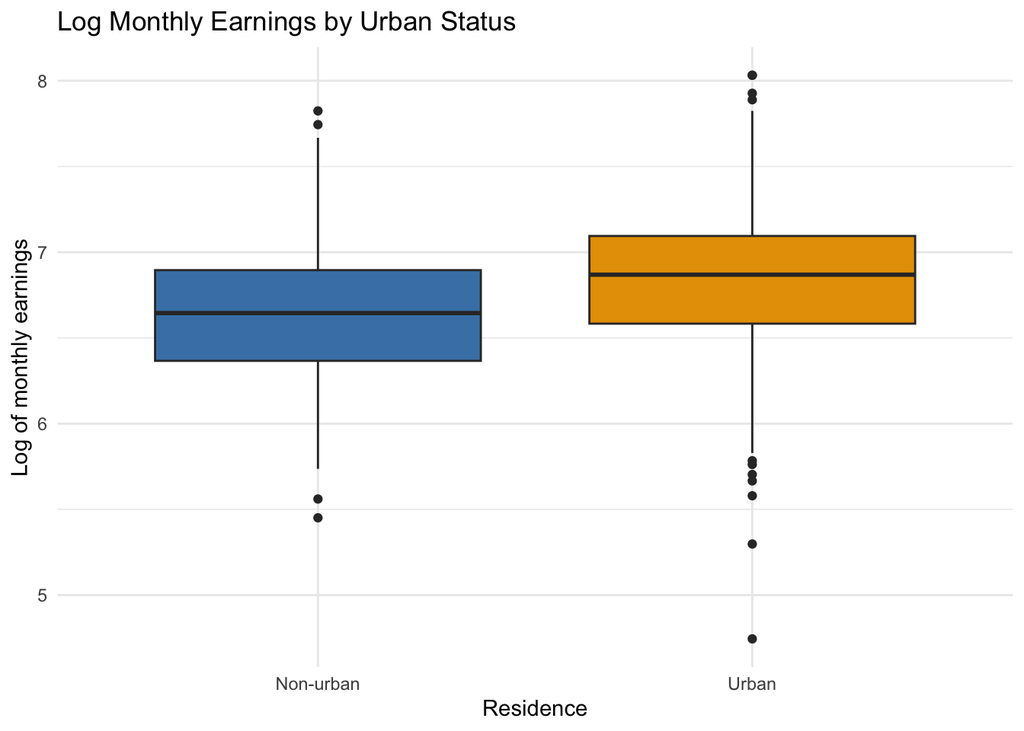

```r
# Create the boxplot here

ggplot(wage2, aes(x = urban_status, y = lwage, fill = urban_status)) +
  geom_boxplot(show.legend = FALSE) +
  scale_fill_manual(values = c("Non-urban" = "steelblue", "Urban" = "#E69F00")) +
  labs(
    title = "Log Monthly Earnings by Urban Status",
    x = "Residence",
    y = "Log of monthly earnings"
  ) +
  theme_minimal()
```

4. Describe the centers, spreads, and overlap. Can this plot by itself establish a population difference?

Urban workers have a higher center, but the distributions overlap substantially. The plot alone cannot establish a population difference.

# 3. Connect a binary regressor to group means

Consider the population model

$$lwage_i=\beta_0+\beta_1 urban_i+u_i.$$

Under the zero conditional mean assumption,

$$E(lwage_i\mid urban_i=0)=\beta_0$$

and

$$E(lwage_i\mid urban_i=1)=\beta_0+\beta_1.$$

So

$$\beta_1=E(lwage_i\mid urban_i=1)-E(lwage_i\mid urban_i=0).$$

5. Interpret $\beta_0$ and $\beta_1$ in this application.

$\beta_0$ is mean log earnings among non-urban workers. $\beta_1$ is urban mean log earnings minus non-urban mean log earnings.

```r
# Estimate lwage on urban and save the model as urban_model
urban_model <- lm(lwage ~ urban, data = wage2)

# Display the model summary as an accessible table
broom::tidy(urban_model) |>
  mutate(
    term = dplyr::recode(
      term,
      `(Intercept)` = "Intercept: mean for non-urban workers",
      urban = "Urban minus non-urban difference",
      .default = term
    ),
    across(c(estimate, std.error, statistic), ~ round(.x, 3)),
    p.value = if_else(
      p.value < 0.001,
      "<0.001",
      format(round(p.value, 3), nsmall = 3)
    )
  ) |>
  select(term, estimate, std.error, statistic, p.value) |>
  knitr::kable(
    caption = "Regression of log monthly earnings on urban status",
    col.names = c(
      "Model term",
      "Coefficient estimate",
      "Standard error",
      "t statistic",
      "p value"
    ),
    align = c("l", "r", "r", "r", "r")
  ) |>
  kableExtra::kable_styling(full_width = FALSE, position = "left") |>
  kableExtra::row_spec(0, bold = TRUE)
```

Regression of log monthly earnings on urban status

| Model term | Coefficient estimate | Standard error | t statistic | p value |
| --- | --- | --- | --- | --- |
| Intercept: mean for non-urban workers | 6.642 | 0.025 | 261.617 | <0.001 |
| Urban minus non-urban difference | 0.191 | 0.030 | 6.358 | <0.001 |

6. Check that the intercept equals one group mean and the slope equals the difference in group means.

```r
# Calculate the fitted mean for urban = 0 and urban = 1 from the coefficients

coefficient_means <- c(
  nonurban = coef(urban_model)["(Intercept)"],
  urban = coef(urban_model)["(Intercept)"] + coef(urban_model)["urban"]
)



# Compare them with the observed group means

observed_means <- tapply(wage2$lwage, wage2$urban, mean)

tibble(
  `Urban status` = c("Non-urban", "Urban"),
  `Mean calculated from model coefficients` = unname(coefficient_means),
  `Observed group mean` = unname(observed_means)
) |>
  mutate(across(where(is.numeric), ~ round(.x, 3))) |>
  knitr::kable(
    caption = "Log monthly earnings means calculated from the model and observed in the sample",
    align = c("l", "r", "r")
  ) |>
  kableExtra::kable_styling(full_width = FALSE, position = "left") |>
  kableExtra::row_spec(0, bold = TRUE)
```

Log monthly earnings means calculated from the model and observed in the sample

| Urban status | Mean calculated from model coefficients | Observed group mean |
| --- | --- | --- |
| Non-urban | 6.642 | 6.642 |
| Urban | 6.833 | 6.833 |

The intercept equals the non-urban mean. Adding the slope produces the urban mean, and the slope equals urban mean minus non-urban mean.

7. Convert the slope from log points to an exact percentage difference using

$$100(e^{\widehat\beta_1}-1).$$

```r
# Calculate the approximate and exact percentage differences

approximate_percent <- 100 * coef(urban_model)["urban"]
exact_percent <- 100 * (exp(coef(urban_model)["urban"]) - 1)

tibble(
  Method = c("Approximate percentage difference", "Exact percentage difference"),
  `Estimated percentage difference` = c(approximate_percent, exact_percent)
) |>
  mutate(`Estimated percentage difference` = round(`Estimated percentage difference`, 1)) |>
  knitr::kable(
    caption = "Approximate and exact urban–non-urban earnings differences",
    align = c("l", "r")
  ) |>
  kableExtra::kable_styling(full_width = FALSE, position = "left") |>
  kableExtra::row_spec(0, bold = TRUE)
```

Approximate and exact urban–non-urban earnings differences

| Method | Estimated percentage difference |
| --- | --- |
| Approximate percentage difference | 19.1 |
| Exact percentage difference | 21.0 |

**Interpretation:**

Urban residence is associated with approximately 21% higher monthly earnings in this sample. This is an association, not a causal effect.

# 4. Construct a hypothesis test by hand

Test

$$H_0:\beta_1=0
\qquad \text{against} \qquad
H_1:\beta_1\neq0.$$

Assuming equal population variances, the pooled variance and conventional standard error are

$$s_p^2=\frac{(n_1-1)s_1^2+(n_0-1)s_0^2}{n_1+n_0-2}$$

and

$$SE(\bar Y_1-\bar Y_0)=
\sqrt{s_p^2\left(\frac{1}{n_1}+\frac{1}{n_0}\right)}.$$

```r
urban_group <- wage2 |> filter(urban == 1)
nonurban_group <- wage2 |> filter(urban == 0)

n_1 <- nrow(urban_group)
n_0 <- nrow(nonurban_group)
mean_1 <- mean(urban_group$lwage)
mean_0 <- mean(nonurban_group$lwage)
var_1 <- var(urban_group$lwage)
var_0 <- var(nonurban_group$lwage)

mean_difference <- mean_1 - mean_0
pooled_variance <- ((n_1 - 1) * var_1 + (n_0 - 1) * var_0) /
  (n_1 + n_0 - 2)
conventional_se <- sqrt(pooled_variance * (1 / n_1 + 1 / n_0))
degrees_freedom <- n_1 + n_0 - 2
t_statistic <- mean_difference / conventional_se
p_value <- 2 * pt(-abs(t_statistic), df = degrees_freedom)

tibble(
  `Coefficient estimate` = mean_difference,
  `Standard error` = conventional_se,
  `t statistic` = t_statistic,
  `Degrees of freedom` = degrees_freedom,
  `p value` = p_value
) |>
  mutate(
    across(c(`Coefficient estimate`, `Standard error`, `t statistic`), ~ round(.x, 3)),
    `Degrees of freedom` = round(`Degrees of freedom`, 0),
    `p value` = if_else(
      `p value` < 0.001,
      "<0.001",
      format(round(`p value`, 3), nsmall = 3)
    )
  ) |>
  knitr::kable(
    caption = "Hand-calculated two-sided test of no urban–non-urban difference",
    align = c("r", "r", "r", "r", "r")
  ) |>
  kableExtra::kable_styling(full_width = FALSE, position = "left") |>
  kableExtra::row_spec(0, bold = TRUE)
```

Hand-calculated two-sided test of no urban–non-urban difference

| Coefficient estimate | Standard error | t statistic | Degrees of freedom | p value |
| --- | --- | --- | --- | --- |
| 0.191 | 0.03 | 6.358 | 933 | <0.001 |

8. At $\alpha=0.05$, what is your decision? State the conclusion in context without saying that you “accept” the null.

At $\alpha=0.05$, reject the null hypothesis of equal population mean log earnings. The sample provides statistically significant evidence of a difference.

9. Explain the p-value in context. Begin with “If the null hypothesis were true…”

If the null hypothesis were true, the p-value is the probability of obtaining a t-statistic at least as far from zero as the observed statistic, in either direction, through sampling variation under the model assumptions.

10. Compare your estimate, standard error, t-statistic, and p-value with `summary(urban_model)`.

The hand calculations match `summary(urban_model)` up to rounding because a binary-regressor OLS model with conventional standard errors is the pooled difference-in-means test.

# 5. Test nonzero null hypotheses

Test $H_0:\beta_1=0.10$ and $H_0:\beta_1=0.20$, using a two-sided alternative in each case.

```r
null_values <- c(0.10, 0.20)

# Calculate a t-statistic and two-sided p-value for each null value

nonzero_tests <- tibble(beta_null = null_values) |>
  mutate(
    t_statistic = (mean_difference - beta_null) / conventional_se,
    p_value = 2 * pt(-abs(t_statistic), df = degrees_freedom),
    decision_5_percent = if_else(p_value <= 0.05, "Reject", "Fail to reject")
  )

nonzero_tests |>
  mutate(
    beta_null = round(beta_null, 2),
    t_statistic = round(t_statistic, 3),
    p_value = if_else(
      p_value < 0.001,
      "<0.001",
      format(round(p_value, 3), nsmall = 3)
    )
  ) |>
  knitr::kable(
    caption = "Two-sided hypothesis tests for nonzero values of the urban coefficient",
    col.names = c(
      "Null value for urban coefficient",
      "t statistic",
      "p value",
      "Decision at the 5 percent level"
    ),
    align = c("r", "r", "r", "l")
  ) |>
  kableExtra::kable_styling(full_width = FALSE, position = "left") |>
  kableExtra::row_spec(0, bold = TRUE)
```

Two-sided hypothesis tests for nonzero values of the urban coefficient

| Null value for urban coefficient | t statistic | p value | Decision at the 5 percent level |
| --- | --- | --- | --- |
| 0.1 | 3.022 | 0.003 | Reject |
| 0.2 | -0.315 | 0.753 | Fail to reject |

11. What is your decision for each test at $\alpha=0.05$? Why can the same sample support different decisions for different null values?

The table reports the decisions. Different proposed values lie at different standardized distances from the estimate, producing different t-statistics and p-values.

# 6. Construct confidence intervals

```r
# Find the 90% and 95% critical values with qt()
t_critical_90 <- qt(0.95, df = degrees_freedom)
t_critical_95 <- qt(0.975, df = degrees_freedom)

# Calculate both confidence intervals
ci_90 <- mean_difference + c(-1, 1) * t_critical_90 * conventional_se
ci_95 <- mean_difference + c(-1, 1) * t_critical_95 * conventional_se

# Display them in a small table
ci_table <- tibble(
  confidence_level = c("90%", "95%"),
  lower = c(ci_90[1], ci_95[1]),
  upper = c(ci_90[2], ci_95[2])
)

ci_table |>
  mutate(across(c(lower, upper), ~ round(.x, 3))) |>
  knitr::kable(
    caption = "Confidence intervals for the urban–non-urban difference in log monthly earnings",
    col.names = c(
      "Confidence level",
      "Lower confidence limit",
      "Upper confidence limit"
    ),
    align = c("l", "r", "r")
  ) |>
  kableExtra::kable_styling(full_width = FALSE, position = "left") |>
  kableExtra::row_spec(0, bold = TRUE)
```

Confidence intervals for the urban–non-urban difference in log monthly earnings

| Confidence level | Lower confidence limit | Upper confidence limit |
| --- | --- | --- |
| 90% | 0.141 | 0.240 |
| 95% | 0.132 | 0.249 |

12. Which interval is wider, and why?

The 95% interval is wider because greater long-run coverage requires a larger critical value and margin of error.

13. Interpret the 95% confidence interval. Then translate its endpoints into percentage differences.

If we repeatedly drew samples and constructed intervals this way, about 95% would contain the true population difference. Transforming the endpoints gives an exact percentage interval of approximately 14.1% to 28.3%.

14. Use the 95% interval to evaluate $H_0:\beta_1=0$, $H_0:\beta_1=0.10$, and $H_0:\beta_1=0.20$.

A proposed value inside the 95% interval is not rejected in the corresponding two-sided 5% test; a value outside it is rejected, when both use the same standard-error assumptions.

```r
# Check the 90% and 95% intervals with confint()
bind_rows(
  as.data.frame(confint(urban_model, level = 0.90)) |>
    tibble::rownames_to_column("Model term") |>
    transmute(
      `Confidence level` = "90%",
      `Model term`,
      `Lower confidence limit` = `5 %`,
      `Upper confidence limit` = `95 %`
    ),
  as.data.frame(confint(urban_model, level = 0.95)) |>
    tibble::rownames_to_column("Model term") |>
    transmute(
      `Confidence level` = "95%",
      `Model term`,
      `Lower confidence limit` = `2.5 %`,
      `Upper confidence limit` = `97.5 %`
    )
) |>
  mutate(
    `Model term` = dplyr::recode(
      `Model term`,
      `(Intercept)` = "Intercept: mean for non-urban workers",
      urban = "Urban minus non-urban difference",
      .default = `Model term`
    ),
    across(c(`Lower confidence limit`, `Upper confidence limit`), ~ round(.x, 3))
  ) |>
  knitr::kable(
    caption = "Confidence intervals calculated with confint for the urban-status regression",
    align = c("l", "l", "r", "r")
  ) |>
  kableExtra::kable_styling(full_width = FALSE, position = "left") |>
  kableExtra::row_spec(0, bold = TRUE)
```

Confidence intervals calculated with confint for the urban-status regression

| Confidence level | Model term | Lower confidence limit | Upper confidence limit |
| --- | --- | --- | --- |
| 90% | Intercept: mean for non-urban workers | 6.600 | 6.684 |
| 90% | Urban minus non-urban difference | 0.141 | 0.240 |
| 95% | Intercept: mean for non-urban workers | 6.592 | 6.692 |
| 95% | Urban minus non-urban difference | 0.132 | 0.249 |

# 7. Conventional versus unequal-variance inference

An unequal-variance standard error for the group difference is

$$SE_{unequal}=\sqrt{\frac{s_1^2}{n_1}+\frac{s_0^2}{n_0}}.$$

```r
unequal_se <- sqrt(var_1 / n_1 + var_0 / n_0)
welch_df <- (var_1 / n_1 + var_0 / n_0)^2 /
  ((var_1 / n_1)^2 / (n_1 - 1) + (var_0 / n_0)^2 / (n_0 - 1))
welch_t <- mean_difference / unequal_se
welch_p <- 2 * pt(-abs(welch_t), df = welch_df)

tibble(
  `Conventional standard error` = conventional_se,
  `Unequal-variance standard error` = unequal_se,
  `Welch t statistic` = welch_t,
  `Welch degrees of freedom` = welch_df,
  `Welch p value` = welch_p
) |>
  mutate(
    across(
      c(
        `Conventional standard error`,
        `Unequal-variance standard error`,
        `Welch t statistic`,
        `Welch degrees of freedom`
      ),
      ~ round(.x, 3)
    ),
    `Welch p value` = if_else(
      `Welch p value` < 0.001,
      "<0.001",
      format(round(`Welch p value`, 3), nsmall = 3)
    )
  ) |>
  knitr::kable(
    caption = "Unequal-variance test results compared with the conventional standard error",
    align = c("r", "r", "r", "r", "r")
  ) |>
  kableExtra::kable_styling(full_width = FALSE, position = "left") |>
  kableExtra::row_spec(0, bold = TRUE)
```

Unequal-variance test results compared with the conventional standard error

| Conventional standard error | Unequal-variance standard error | Welch t statistic | Welch degrees of freedom | Welch p value |
| --- | --- | --- | --- | --- |
| 0.03 | 0.029 | 6.518 | 507.347 | <0.001 |

15. Does the standard-error choice change the conclusion? Why should the method still be reported?

The method may change the standard error and p-value even when it does not change the decision. Researchers should report it because inference depends on variance assumptions.

```r
# Verify the pooled and Welch tests with t.test()
bind_rows(
  broom::tidy(t.test(lwage ~ urban_status, data = wage2, var.equal = TRUE)) |>
    mutate(`Variance assumption` = "Equal variances"),
  broom::tidy(t.test(lwage ~ urban_status, data = wage2, var.equal = FALSE)) |>
    mutate(`Variance assumption` = "Unequal variances")
) |>
  transmute(
    `Variance assumption`,
    `Non-urban mean` = estimate1,
    `Urban mean` = estimate2,
    `Non-urban minus urban difference` = estimate,
    `t statistic` = statistic,
    `Degrees of freedom` = parameter,
    `p value` = p.value,
    `Lower 95 percent confidence limit` = conf.low,
    `Upper 95 percent confidence limit` = conf.high
  ) |>
  mutate(
    across(
      c(
        `Non-urban mean`,
        `Urban mean`,
        `Non-urban minus urban difference`,
        `t statistic`,
        `Degrees of freedom`,
        `Lower 95 percent confidence limit`,
        `Upper 95 percent confidence limit`
      ),
      ~ round(.x, 3)
    ),
    `p value` = if_else(
      `p value` < 0.001,
      "<0.001",
      format(round(`p value`, 3), nsmall = 3)
    )
  ) |>
  knitr::kable(
    caption = "Equal-variance and Welch two-sample t tests for log monthly earnings",
    align = c("l", "r", "r", "r", "r", "r", "r", "r", "r")
  ) |>
  kableExtra::kable_styling(full_width = FALSE, position = "left") |>
  kableExtra::row_spec(0, bold = TRUE) |>
  kableExtra::scroll_box(width = "100%")
```

Equal-variance and Welch two-sample t tests for log monthly earnings

| Variance assumption | Non-urban mean | Urban mean | Non-urban minus urban difference | t statistic | Degrees of freedom | p value | Lower 95 percent confidence limit | Upper 95 percent confidence limit |
| --- | --- | --- | --- | --- | --- | --- | --- | --- |
| Equal variances | 6.642 | 6.833 | -0.191 | -6.358 | 933.000 | <0.001 | -0.249 | -0.132 |
| Unequal variances | 6.642 | 6.833 | -0.191 | -6.518 | 507.347 | <0.001 | -0.248 | -0.133 |

Note: `t.test()` reports the first factor level minus the second. With Non-urban first, its estimate has the opposite sign from the regression slope, though the magnitude and two-sided p-value agree.

# 8. Statistical significance and causal language

16. A classmate writes: “Living in an urban area causes monthly earnings to increase.” Rewrite the claim so it is supported by this analysis.

Supported statement: “Urban workers have higher average monthly earnings than non-urban workers in this sample,” followed by the estimated percentage difference.

17. Name two factors that could affect earnings and be systematically different between urban and non-urban workers. What would leaving them out mean for $E(u\mid urban)=0$?

Examples include education, occupation, industry, experience, local price levels, and regional labor-market conditions. If an omitted factor affects earnings and differs systematically by urban status, $E(u | urban) = 0$ fails and the coefficient may be biased.

18. Is statistical significance the same as practical importance? What additional context would help you evaluate the size/ magnitude?

Statistical significance measures evidence against a null relative to sampling uncertainty. Practical importance requires context such as dollar earnings, local cost-of-living differences, and comparisons with other earnings gaps.

# 9. Final synthesis

In 4–6 sentences, summarize the estimated difference, uncertainty, hypothesis-test result, and one important limitation. Use percentage language and avoid causal language.

One possible response: Urban workers earn approximately 21% more per month than non-urban workers in this sample. The 95% interval corresponds to an exact percentage difference of approximately 14.1% to 28.3%. The test of no population difference is rejected at the 5% level. Unequal-variance inference can be compared with the conventional result. The analysis is associational because other differences between urban and non-urban workers may explain part of the gap.

# Optional extension: sampling variability

Draw 500 bootstrap samples, estimate the urban coefficient in each, and plot its sampling distribution. Compare its center and standard deviation with the original estimate and conventional standard error.

```r
set.seed(8300)

# Write the bootstrap simulation here

n <- nrow(wage2)

bootstrap_slopes <- replicate(500, {
  bootstrap_sample <- wage2[
    sample(seq_len(n), size = n, replace = TRUE),
  ]

  coef(
    lm(lwage ~ urban, data = bootstrap_sample)
  )[["urban"]]
})
```

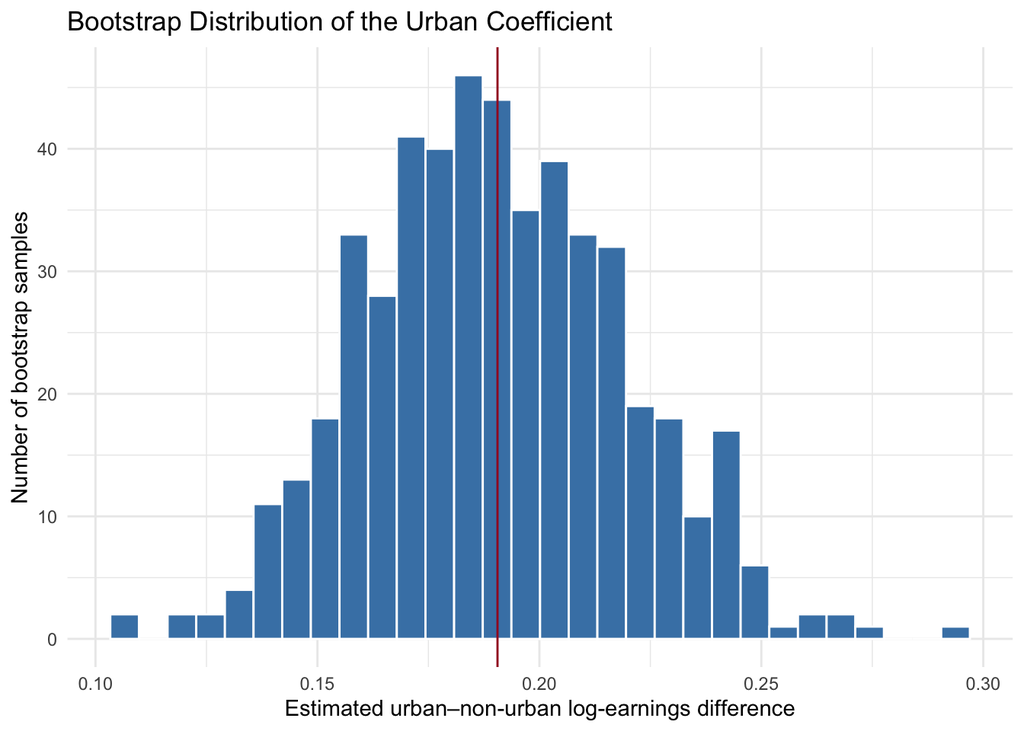

```r
tibble(beta_1_hat = bootstrap_slopes) |>
  ggplot(aes(x = beta_1_hat)) +
  geom_histogram(
    bins = 30,
    fill = "steelblue",
    color = "white"
  ) +
  geom_vline(
    xintercept = coef(urban_model)[["urban"]],
    color = "#A30D26"
  ) +
  labs(
    title = "Bootstrap Distribution of the Urban Coefficient",
    x = "Estimated urban–non-urban log-earnings difference",
    y = "Number of bootstrap samples"
  ) +
  theme_minimal()
```